Maryland Covid Analysis by John Doggett.

The purpose of this data project is to analysis covid infections and deaths in the State of Maryland. We want to see if there were certain predictors for covid deaths or infections. We want to see if different groups of people were differently affected by covid. The reason for this is to bring awareness to make predictions on what causes higher death rate from covid and bring awareness difference of how covid affected different groups.

From this, we will appreciate the importance of preventing infections and how they may relate to hospitilizations and death.

The dataset I am using is from Maryland's Opendata website, which has lots of public avaliable datasets you can download. I am using the MD COVID-19 - MASTER Case Tracker. This dataset tracks daily updates on COVID-19 Infections in MD, starting from March 04, 2020. The data set breaks downs columns in this way (I grouped them):

The date of the update

Total Cases Case Delta (New cases today)

Total Covid Tests done Covid Test Delta PosTestPercent (7 Day average) PosTestDifference (the difference in 7 day average from yesterday) Total number of negative Tests Negative Test Dela

Total number of hospital beds Total number of acute care hospital beds Total number of ICU beds Delta of Total Number of Hospital Beds Cumulative Number of people Hospitalized Delta of Cumulative Number of people Hospitalized Cumulative Number of People Released from Isolation Delta of Cumulative Number of People Released from Isolation

For each county, the total number of cumulative cases

Cumulative Infections in various ages groups, first non-adult, adult, and senior, then broken up by 10 year ages Cumulative Cases for each gender Cumulative Cases for each race

Cumulative deaths Delta of Deaths Deaths cumulative by each county Deaths cumulative by 10 year ages Deaths cumulative by each gender Deaths cumulative by each race

Again the same columns for probable deaths as for deaths

Then adult and pediatric acute hospitalizations and icuhospitalizations.

The data set can be downloaded here: https://opendata.maryland.gov/Health-and-Human-Services/MD-COVID-19-MASTER-Case-Tracker/mgd3-qk8t Im going to download the CSV and read it using Pandas, a python data science library for managing data (https://pandas.pydata.org/docs/).

```python
import pandas as pd #Import pandas

df = pd.read_csv("https://opendata.maryland.gov/api/views/mgd3-qk8t/rows.csv?accessType=DOWNLOAD&bom=true&format=true")
print(len(df)) #Check number of rows
df.head() # Make sure it works!
```

```
1018
```

|  | Filter | ReportDate | TotalCases | CaseDelta | TotalTests | TestsDelta | PosTestPercent | PosPercentDiff | NegativeTests | NegDelta | ... | pDeathAfrAmer | pDeathWhite | pDeathHispanic | pDeathAsian | pDeathOther | pDeathNotAvail | adultacutehospitalizations | adulticuhospitalizations | pedacutehospitalizations | pedicuhospitalizations |
| --- | --- | --- | --- | --- | --- | --- | --- | --- | --- | --- | --- | --- | --- | --- | --- | --- | --- | --- | --- | --- | --- |
| 0 | NaN | 03/04/2020 10:00:00 AM | 0 | 0 | 0 | 0 | 0.0 | 0.0 | 0 | 0 | ... | 0.0 | 0.0 | 0.0 | 0.0 | 0.0 | 0 | 0 | 0 | 0 | 0 |
| 1 | NaN | 03/05/2020 10:00:00 AM | 3 | 3 | 0 | 0 | 0.0 | 0.0 | 0 | 0 | ... | 0.0 | 0.0 | 0.0 | 0.0 | 0.0 | 0 | 0 | 0 | 0 | 0 |
| 2 | NaN | 03/06/2020 10:00:00 AM | 3 | 0 | 0 | 0 | 0.0 | 0.0 | 0 | 0 | ... | 0.0 | 0.0 | 0.0 | 0.0 | 0.0 | 0 | 0 | 0 | 0 | 0 |
| 3 | NaN | 03/07/2020 10:00:00 AM | 3 | 0 | 0 | 0 | 0.0 | 0.0 | 0 | 0 | ... | 0.0 | 0.0 | 0.0 | 0.0 | 0.0 | 0 | 0 | 0 | 0 | 0 |
| 4 | NaN | 03/08/2020 10:00:00 AM | 5 | 2 | 0 | 0 | 0.0 | 0.0 | 0 | 0 | ... | 0.0 | 0.0 | 0.0 | 0.0 | 0.0 | 0 | 0 | 0 | 0 | 0 |

5 rows × 163 columns

Now we need to clean up this data set. I see the first column is something can just be removed. I also want to remove probable deaths, and columns that are unknown.

```python
#Print columns to choose which ones to remove
for col in df.columns:
    print(col, end=' ')
```

```
Filter ReportDate TotalCases CaseDelta TotalTests TestsDelta PosTestPercent PosPercentDiff NegativeTests NegDelta bedsTotal bedsAcute bedsICU bedsDelta total_hospitalized hospitalizedDelta total_released releasedDelta ALLE ANNE BALT BCITY CALV CARO CARR CECI CHAR DORC FRED GARR HARF HOWA KENT MONT P…
```

```python
#Remove unknown columns and filter column
df = df.drop('Filter', axis=1)
df = df.drop('UNKN', axis=1)
df = df.drop('caseAgeUnknown', axis=1)
df = df.drop('genUnkn', axis=1)
df = df.drop('caseNotAVail', axis=1)
df = df.drop('deathUNKN', axis=1)
df = df.drop('deathAgeUnknown', axis=1)
df = df.drop('deathGenUnkn', axis=1)
df = df.drop('deathNotAvail', axis=1)

#Remove all columns related to probable death
columns = list(df.columns.values)
for x in columns:
    if "pDeath" in x:
        df = df.drop(x, axis=1)

df.head()
```

|  | ReportDate | TotalCases | CaseDelta | TotalTests | TestsDelta | PosTestPercent | PosPercentDiff | NegativeTests | NegDelta | bedsTotal | ... | deathGenFemale | deathAfrAmer | deathWhite | deathHispanic | deathAsian | deathOther | adultacutehospitalizations | adulticuhospitalizations | pedacutehospitalizations | pedicuhospitalizations |
| --- | --- | --- | --- | --- | --- | --- | --- | --- | --- | --- | --- | --- | --- | --- | --- | --- | --- | --- | --- | --- | --- |
| 0 | 03/04/2020 10:00:00 AM | 0 | 0 | 0 | 0 | 0.0 | 0.0 | 0 | 0 | 0 | ... | 0 | 0 | 0 | 0 | 0.0 | 0.0 | 0 | 0 | 0 | 0 |
| 1 | 03/05/2020 10:00:00 AM | 3 | 3 | 0 | 0 | 0.0 | 0.0 | 0 | 0 | 0 | ... | 0 | 0 | 0 | 0 | 0.0 | 0.0 | 0 | 0 | 0 | 0 |
| 2 | 03/06/2020 10:00:00 AM | 3 | 0 | 0 | 0 | 0.0 | 0.0 | 0 | 0 | 0 | ... | 0 | 0 | 0 | 0 | 0.0 | 0.0 | 0 | 0 | 0 | 0 |
| 3 | 03/07/2020 10:00:00 AM | 3 | 0 | 0 | 0 | 0.0 | 0.0 | 0 | 0 | 0 | ... | 0 | 0 | 0 | 0 | 0.0 | 0.0 | 0 | 0 | 0 | 0 |
| 4 | 03/08/2020 10:00:00 AM | 5 | 2 | 0 | 0 | 0.0 | 0.0 | 0 | 0 | 0 | ... | 0 | 0 | 0 | 0 | 0.0 | 0.0 | 0 | 0 | 0 | 0 |

5 rows × 107 columns

```python
#Print columns to see remaining
for col in df.columns:
    print(col, end=' ')
```

```
ReportDate TotalCases CaseDelta TotalTests TestsDelta PosTestPercent PosPercentDiff NegativeTests NegDelta bedsTotal bedsAcute bedsICU bedsDelta total_hospitalized hospitalizedDelta total_released releasedDelta ALLE ANNE BALT BCITY CALV CARO CARR CECI CHAR DORC FRED GARR HARF HOWA KENT MONT PRIN QUE…
```

Thankfully this dataset is a coalesced form over every covid infection for that day, so cleaning up bad data will be a lot easier. If you load up this dataset into Excel you will see some patterns of missing data. In february 2022, we stop counting negative tests. In December 2021, we stop counting Hospitalizations (aka total_hospitalized - releasedDelta). Between 12/05/21 and 12/28/21 there is a hole in counting deaths from covid. Under 18, 18 to 64, and 65 plus for infections are never used. Data on infections in hispanics is not collected till 4/15/2020, so analysis of infections in race before this date cannot be done. Since 04/08/22, updates to deaths are only recorded on weekdays. Pediatric hospitalizations doesn't seem to be used until 09/02/21

```python
df = df.drop('under18', axis=1)
df = df.drop('18to64', axis=1)
df = df.drop('65plus', axis=1)
#Drop unused columns
```

```python
import builtins
import numpy #Library for advanced number types for python... basically every good library uses it, but since we need to directly access it here we need to import

#Fill in missing death data
before = df.iloc[640]
display(before)
after = df.iloc[664]
display(after)
print(before.iloc[57])
print(after.iloc[57])
print(before.iloc[99])
print(after.iloc[99])
#We need to predict rows 641-663 with their columns 57-99, however DOD makes no sense so we'll just ignore it
for x in range(57,100):
    top = (before.iloc[x])
    bottom = after.iloc[x]

    # A complicated system to convert to int because the df is a mix of numpyf64 and string
    top_type = type(top)
    match (top_type):
        case builtins.str:
            #print(f"{top_type} is a String")
            top = int(top.replace(',', ''))
            bottom = int(bottom.replace(',', ''))
        case numpy.float64:
            #print(f"{top_type} is a numpyf64")
            top = top.astype(int).item()
            bottom = bottom.astype(int).item()


    diff = bottom-top

    if (x != 58):
        for y in range(641,664):
            df.iloc[y,x] = round(diff * ((y - 640)) / 24) + top


    #Set death dif
    if (x == 58):
        for y in range(641,664):
            today = df.iloc[y,x-1]
            prev = df.iloc[y-1,x-1]
            if(y == 641):
                prev = int(prev.replace(',', ''))
            df.iloc[y,x] = today-prev
```

```
ReportDate                    12/04/2021 10:00:00 AM
TotalCases                                   592,679
CaseDelta                                      1,866
TotalTests                                15,198,334
TestsDelta                                    45,443
                                       ...
deathOther                                     122.0
adultacutehospitalizations                       585
adulticuhospitalizations                         191
pedacutehospitalizations                           3
pedicuhospitalizations                             3
Name: 640, Length: 104, dtype: object
```

```
ReportDate                    12/28/2021 10:00:00 AM
TotalCases                                   680,351
CaseDelta                                      7,280
TotalTests                                16,067,339
TestsDelta                                    44,324
                                       ...
deathOther                                     123.0
adultacutehospitalizations                     1,452
adulticuhospitalizations                         355
pedacutehospitalizations                          16
pedicuhospitalizations                             3
Name: 664, Length: 104, dtype: object
```

```
11,022
11,437
122.0
123.0
```

Finally we've done some data work, now lets print graphs to see some patterns. We will use matplotlib and seaborn to print graphs (https://seaborn.pydata.org/generated/seaborn.lineplot.html). Im going to print line plots to view patterns of data.

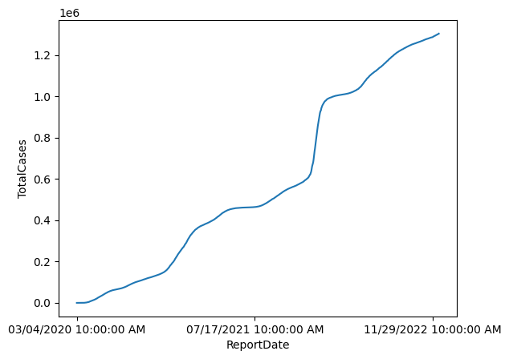

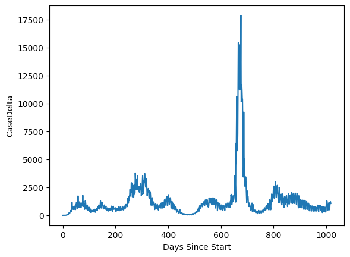

```python
import seaborn #Library for printing graphs
from matplotlib import pyplot as plt

df2 = df.copy()
#pd.to_datetime(df2['ReportDate'], utc=False)
#Add days sense column
for x in range(0,len(df2)):
    df2.loc[x, "Days Since Start"] =  x;

#Convert total infections to int
for x in range(0,len(df2)):
    df2.iloc[x,1] = int((df2.iloc[x,1]).replace(',', ''))

#Print death cumulative over time
ax = seaborn.lineplot(x =df2["ReportDate"], y=df2["TotalCases"])

ax.set_yscale('linear')
ax.set_xticks([df2.iloc[0,0], df2.iloc[500,0],df2.iloc[1000,0]])
plt.show()

pos = df2.columns.get_loc('CaseDelta')
for x in range(0,len(df2)):
    if (type(df2.iloc[x, pos]) == builtins.str):
        df2.iloc[x, pos] = int((df2.iloc[x, pos]).replace(',', ''))
ax = seaborn.lineplot(x =df2["Days Since Start"], y=df2["CaseDelta"])
plt.show()
```

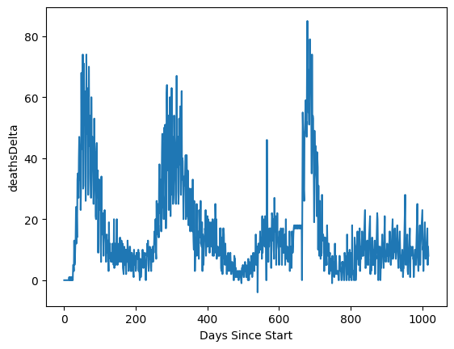

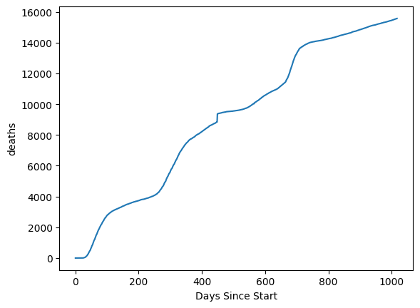

```python
#Lets now also print DeathDelta
df3 = df2.loc[(df2['deaths'] != 0) | (df2['Days Since Start'] < 20)]

ax = seaborn.lineplot(x =df3["Days Since Start"], y=df3["deathsDelta"])
plt.show()
pos = df3.columns.get_loc('deaths')
for x in range(0,len(df3)):
    if (type(df3.iloc[x, pos]) == builtins.str):
        df3.iloc[x, pos] = int((df3.iloc[x, pos]).replace(',', ''))
    #df2.iloc[x,1] = int((df2.iloc[x,1]).replace(',', ''))
ax = seaborn.lineplot(x =df3["Days Since Start"], y=df3["deaths"])
plt.show()
```

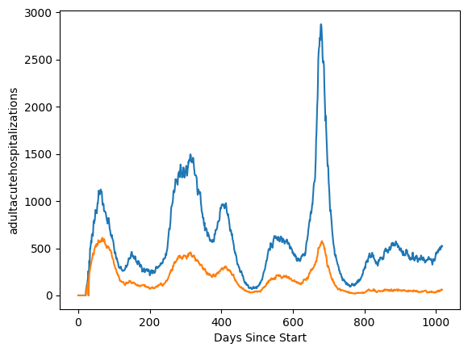

```python
pos = df2.columns.get_loc('adultacutehospitalizations')
for x in range(0,len(df2)):
    if (type(df2.iloc[x, pos]) == builtins.str):
        df2.iloc[x, pos] = int((df2.iloc[x, pos]).replace(',', ''))
pos = df2.columns.get_loc('adulticuhospitalizations')
for x in range(0,len(df2)):
    if (type(df2.iloc[x, pos]) == builtins.str):
        df2.iloc[x, pos] = int((df2.iloc[x, pos]).replace(',', ''))

seaborn.lineplot(x=df2["Days Since Start"], y=df2["adultacutehospitalizations"])
seaborn.lineplot(x=df2["Days Since Start"], y=df2["adulticuhospitalizations"])
```

We can see a general trend of spikes of infections leading to increased delta of deaths and cumulative deaths, as well as increased hospitalizations. This is not surprising.

However, there are a few things I wish to look at and hypothesis.

Is the rate of delta cases linear to rate of delta deaths? One might believe that if there is lots of hospitalizations, care for patients will decreases and deaths will go up. If this is the case, the death rate should remain the same throughout time.

Are any groups of races or counties dispraportionally affected by covid? Are their deathrates different?

I will run a regression test of hospitalization increases vs infection increases. My Null Hyopthesis is that there is no correlation.

We can use SKlearn to run the regression test (https://scikit-learn.org/stable/auto_examples/linear_model/plot_ols.html). Seaborn will make the regression plot for us (https://seaborn.pydata.org/generated/seaborn.regplot.html)

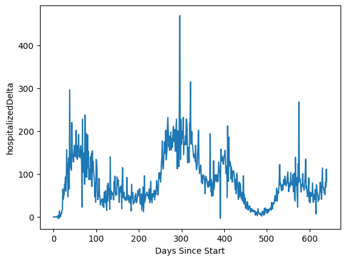

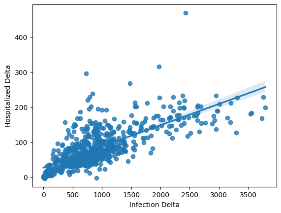

```python
#Let us find the regression between delta hospitalization and delta case. Delta hospitalization data ends in Dec 2021, so our analysis will be before then.
#Is Delta Case and Delta Hospitalization linear, or is it exponential?
df4 = df2.copy()
df4 = df4.loc[((df4['Days Since Start'] < 641) & (df4['hospitalizedDelta'] != 0)) | (df4['Days Since Start'] < 20) ] #Remove some empty holes for hospitalization tracking

pos = df4.columns.get_loc('hospitalizedDelta')
for x in range(0,len(df4)):
    if (type(df4.iloc[x, pos]) == builtins.str):
        df4.iloc[x, pos] = int((df4.iloc[x, pos]).replace(',', ''))


pos = df4.columns.get_loc('CaseDelta')
for x in range(0,len(df4)):
    if (type(df4.iloc[x, pos]) == builtins.str):
        df4.iloc[x, pos] = int((df4.iloc[x, pos]).replace(',', ''))



ax = seaborn.lineplot(x =df4["Days Since Start"], y=df4["hospitalizedDelta"])
plt.show()

caseDelta = pd.Series(df4.CaseDelta)





hDelta = pd.Series(df4.hospitalizedDelta)

ax = seaborn.regplot(x=caseDelta.tolist(), y=hDelta.tolist())
ax.set_ylabel("Hospitalized Delta")
ax.set_xlabel("Infection Delta")

plt.show()
```

```python
#Seems like theres a correlation between Hospitalized Delta and Infected Delta, lets get that correlation with SKLearn, a ML Library
from sklearn import *
x = caseDelta.values.reshape(-1, 1)
y = hDelta.values
model = sklearn.linear_model.LinearRegression().fit(x, y)
print("Y intercep\t\tSlope\t\tScore");
print(model.intercept_, model.coef_, model.score(x, y))
```

```
Y intercep		Slope		Score
26.834829423185077 [0.06064018] 0.5481641293206584
```

With a strong correlation of R^2 = 0.54, it is not suprising that Hospitilizations increase when there is more infections, I reject the null hypothesis. This is obvious. But what about death rate. Unfortunently, this is not trivial to calculate, we have to do some averages. The dataset does not keep track of deathrates of individual cases. One a certain day, someone who died was infected many days ago. We can aproximate the deathrate of the day by taking the average deathrate of summing the past two week's delta deaths divided by sum delta infections.

I want to find out if heavy amounts of hospitalizations cause a higher deather rate. My Null Hypothesis is that there is no correlation between death rates and number of people hospitalized.

```python
#First let's calculate the 14 day death count rate. This is calculated by adding up delta death for the pass 14 days, and dividing by sum of delta infections.

pos_delta_d = df4.columns.get_loc('deathsDelta')
pos_delta_i = df4.columns.get_loc('CaseDelta')

death_rate = []
for x in range (0, len(df4)):
    sum_infections = 0;
    sum_death = 0;
    lower = x - 13;
    if (lower < 0):
        lower = 0

    for y in range(lower,x + 1):
        sum_infections = sum_infections + df4.iloc[y,pos_delta_i]
        sum_death = sum_death + df4.iloc[y,pos_delta_d]
    rate = 0;
    if (sum_infections != 0):
        rate = sum_death / sum_infections;
    #print(rate)
    death_rate.append(rate)
df4["deathRate"] = death_rate
```

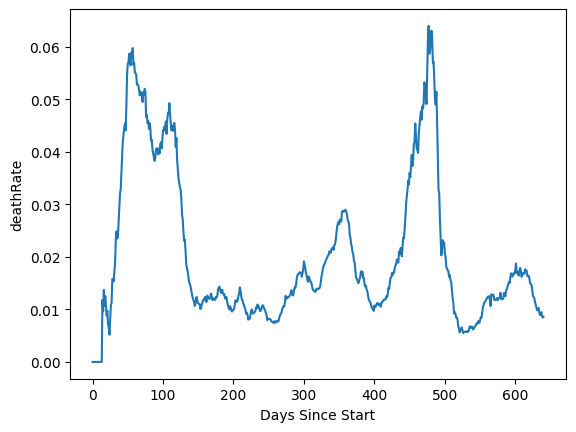

```python
#Lets print it
ax = seaborn.lineplot(x =df4["Days Since Start"], y=df4["deathRate"])
```

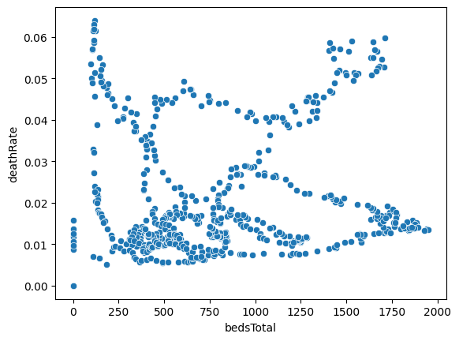

```python
pos = df4.columns.get_loc('bedsTotal')
for x in range(0,len(df4)):
    if (type(df4.iloc[x, pos]) == builtins.str):
        df4.iloc[x, pos] = int((df4.iloc[x, pos]).replace(',', ''))

beds_total = pd.Series(df4.bedsTotal)

seaborn.scatterplot(x = df4["bedsTotal"], y=df4["deathRate"])
```

This is hard to analysis visablly. Let's use least squares to see if there is a correlation. Statsmodels is another library that can do statistics for us (https://www.statsmodels.org/dev/generated/statsmodels.regression.linear_model.OLS.html).

```python
import statsmodels.formula.api as smf
mod = smf.ols("Q('deathRate') ~ bedsTotal", data=df4).fit()
mod.summary()
```

OLS Regression Results

| Dep. Variable: | Q('deathRate') | R-squared: | 0.899 |
| --- | --- | --- | --- |
| Model: | OLS | Adj. R-squared: | 0.477 |
| Method: | Least Squares | F-statistic: | 2.131 |
| Date: | Fri, 16 Dec 2022 | Prob (F-statistic): | 5.23e-07 |
| Time: | 21:47:52 | Log-Likelihood: | 2513.5 |
| No. Observations: | 636 | AIC: | -4001. |
| Df Residuals: | 123 | BIC: | -1715. |
| Df Model: | 512 |  |  |
| Covariance Type: | nonrobust |  |  |

|  | coef | std err | t | P>\|t\| | [0.025 | 0.975] |
| --- | --- | --- | --- | --- | --- | --- |
| Intercept | 0.0045 | 0.002 | 2.036 | 0.044 | 0.000 | 0.009 |
| bedsTotal[T.97] | 0.0490 | 0.011 | 4.536 | 0.000 | 0.028 | 0.070 |
| bedsTotal[T.100] | 0.0456 | 0.011 | 4.225 | 0.000 | 0.024 | 0.067 |
| bedsTotal[T.104] | 0.0486 | 0.008 | 6.233 | 0.000 | 0.033 | 0.064 |
| bedsTotal[T.107] | 0.0524 | 0.011 | 4.849 | 0.000 | 0.031 | 0.074 |
| bedsTotal[T.108] | 0.0026 | 0.011 | 0.236 | 0.814 | -0.019 | 0.024 |
| bedsTotal[T.111] | 0.0284 | 0.011 | 2.629 | 0.010 | 0.007 | 0.050 |
| bedsTotal[T.112] | 0.0569 | 0.011 | 5.272 | 0.000 | 0.036 | 0.078 |
| bedsTotal[T.113] | 0.0277 | 0.011 | 2.565 | 0.012 | 0.006 | 0.049 |
| bedsTotal[T.115] | 0.0482 | 0.006 | 8.417 | 0.000 | 0.037 | 0.060 |
| bedsTotal[T.116] | 0.0547 | 0.011 | 5.067 | 0.000 | 0.033 | 0.076 |
| bedsTotal[T.118] | 0.0470 | 0.011 | 4.349 | 0.000 | 0.026 | 0.068 |
| bedsTotal[T.119] | 0.0504 | 0.008 | 6.461 | 0.000 | 0.035 | 0.066 |
| bedsTotal[T.120] | 0.0189 | 0.008 | 2.420 | 0.017 | 0.003 | 0.034 |
| bedsTotal[T.122] | 0.0158 | 0.011 | 1.463 | 0.146 | -0.006 | 0.037 |
| bedsTotal[T.125] | 0.0570 | 0.011 | 5.281 | 0.000 | 0.036 | 0.078 |
| bedsTotal[T.131] | 0.0155 | 0.011 | 1.435 | 0.154 | -0.006 | 0.037 |
| bedsTotal[T.132] | 0.0176 | 0.011 | 1.632 | 0.105 | -0.004 | 0.039 |
| bedsTotal[T.133] | 0.0344 | 0.011 | 3.183 | 0.002 | 0.013 | 0.056 |
| bedsTotal[T.134] | 0.0166 | 0.008 | 2.129 | 0.035 | 0.001 | 0.032 |
| bedsTotal[T.137] | 0.0187 | 0.011 | 1.730 | 0.086 | -0.003 | 0.040 |
| bedsTotal[T.138] | 0.0137 | 0.011 | 1.271 | 0.206 | -0.008 | 0.035 |
| bedsTotal[T.139] | 0.0132 | 0.011 | 1.221 | 0.224 | -0.008 | 0.035 |
| bedsTotal[T.146] | 0.0219 | 0.006 | 3.370 | 0.001 | 0.009 | 0.035 |
| bedsTotal[T.150] | 0.0462 | 0.011 | 4.277 | 0.000 | 0.025 | 0.068 |
| bedsTotal[T.152] | 0.0128 | 0.011 | 1.181 | 0.240 | -0.009 | 0.034 |
| bedsTotal[T.153] | 0.0477 | 0.011 | 4.418 | 0.000 | 0.026 | 0.069 |
| bedsTotal[T.154] | 0.0446 | 0.011 | 4.131 | 0.000 | 0.023 | 0.066 |
| bedsTotal[T.157] | 0.0450 | 0.011 | 4.162 | 0.000 | 0.024 | 0.066 |
| bedsTotal[T.159] | 0.0121 | 0.011 | 1.118 | 0.266 | -0.009 | 0.033 |

[output cut: 483 more lines]

| Omnibus: | 183.892 | Durbin-Watson: | 1.653 |
| --- | --- | --- | --- |
| Prob(Omnibus): | 0.000 | Jarque-Bera (JB): | 3852.235 |
| Skew: | 0.740 | Prob(JB): | 0.00 |
| Kurtosis: | 14.966 | Cond. No. | 122. |

Notes:  
[1] Standard Errors assume that the covariance matrix of the errors is correctly specified.

Let us do one more test to see if the death rates between state average and each county was different. This is a simple Z proportion test, where we know the average death rate as of 12/16 overall for MD, and for each county. Our Null hypothesis is that each county had the same death rate as the state average. Scipy provides a way to convert Z score to probability, I'm doing the Z score calculations myself.

https://www.statology.org/two-proportion-z-test/ https://docs.scipy.org/doc/scipy/reference/generated/scipy.stats.norm.html

```python
#Now Lets calulate the death rate in each county. There are 23 counties + City of Baltimore.
import scipy
import math

infect_pos = df.columns.get_loc('ALLE')
death_pos = df.columns.get_loc('deathALLE')
row_num = len(df) - 1
column_names = df.columns

last = df.iloc[row_num]
total_deaths = int(last["deaths"].replace(',', ''))
total_infections = int(last["TotalCases"].replace(',', ''))
MD_Death_Rate = total_deaths / total_infections;
print("Average MD Death Rate")
print(MD_Death_Rate)



for x in range(0,24):

    infections = df.iloc[row_num,infect_pos + x]
    if (type(infections) == builtins.str) :
        infections = int((infections).replace(',', ''))

    deaths = df.iloc[row_num,death_pos + x]
    if (type(deaths) == builtins.str):
        deaths = int((deaths).replace(',', ''))

    rate = deaths/infections

    p = (rate*infections + MD_Death_Rate * total_infections) / (infections + total_infections)

    top = (MD_Death_Rate - rate)
    bottom = p * (1 - p) * (1/infections + 1/total_infections)
    bottom = math.sqrt(bottom)

    Z = top/bottom

    #survivors = numpy.array([[infections - deaths,deaths], [total_infections - total_deaths, total_deaths]])
    print(column_names[infect_pos + x])
    print(rate)
    print(scipy.stats.norm.sf(abs(Z)) * 2)
    #print(scipy.stats.chi2_contingency(survivors)[1])
```

```
Average MD Death Rate
0.011945584888815941
ALLE
0.018082663605051664
7.005415811842047e-16
ANNE
0.01056037113905506
3.198848752558757e-05
BALT
0.016159135261324467
6.60630370169003e-48
BCITY
0.013092648673599988
0.00016172183972969244
CALV
0.011294649159960469
0.47802002370511965
CARO
0.012291607798813223
0.7893055284399152
CARR
0.016408726459071415
3.2568705380571853e-11
CECI
0.014168684630841363
0.004713250704236419
CHAR
0.010604453870625663
0.019375468445120846
DORC
0.012282608695652173
0.7668657763442754
FRED
0.010131459251199543
0.00010298798668515868
GARR
0.01795096322241681
5.169633086078533e-06
HARF
0.013295981937533972
```

[output cut: 19 more lines]

```
STMA
0.010007208582453462
0.006540396623218158
TALB
0.015116613878491218
0.015330434608551501
WASH
0.01517231053327677
5.440666086617557e-09
WICO
0.014547436381167986
0.00025384335305696676
WORC
0.01687925577826796
4.001399682152421e-06
```

We ran Z Proportion with each county vs the state average. Almost all the counties had a poor probability of having equal proportion of deathrate to the state except for Calvert, Caroline, Dorchester, and Somerset, we reject the Null hypothesis for those counties that did have a low probabiltiy of having equal proportion to the state.

This means there were disparities in how covid affects these counties. The state should probably do further analysis as to why some counties were so statistically different in death rate than the state average.